# A Throughout Analysis on Amazon Stock Price

4/26/2020

Stock investments are one of the most popular ways for people to choose to grow their wealth. According to data from yahoo finance, Amazon went for IPO on May 15th, 1997, with an IPO price of $18 per share. There had been two 2-for-1 split and one 3-for-1 split. So if someone bought 100 shares of amazon stock with $1,800 in 1997, and still holding those stocks today, that money would grow to 100*2*2*3*2366 = $2,839,200 (calculated by amazon stock price on 4/27/2020). That is 157,733% of overall return in 23 years without adjusting inflation. The massive growth in stock price also sent Jeff Bezos to become the richest man in the world.

However, as an average investor (and a student took stats courses), how could someone like me benefit from the stock growth? Therefore, in this report, I will try to analyze the performance of amazon stock with the last 10 years of performance with different techniques, including ARMA (ARIMA models), GARCH model, and using pomp package to do the financial analysis. The ultimate goal is to try to provide some insight to readers about information and predictions about Amazon stock. Therefore, try to provide some investment insights.

[output not shown]

## Read in Data

The data is a daily data consists of a total of 2,518 data points. The data are ranging from 4/26/2010 to 4/24/2020. We will first plot out the data and see how it looks like. The variable we interested in is the adjusted close price.

```r
AMZN <- read.csv("amzn.csv",sep=",",header=TRUE)
AMZN$log_close <- log(AMZN$Adj.Close)
diff <- diff(AMZN$log_close)
demean <- diff - mean(diff)
```

## Plot the data

I will show three different plots for this dataset. First, I will plot the relationship between time and the adjusted close price. Then I will plot the relationship between time and log-transformed adjusted close price. Finally, I will plot the relationship between time and difference of log return.

The difference of log return is defined as following:

Let’s denote the Amazon stock price on day t is $Z_t$, then difference of log return $D_t$ is defined as
$$D_t = log(Z_t) - log(Z_{t-1})$$

The reason we want to see the difference in log return is that differenced data is typically mean stationary. We will see such characteristics in the following third plot.

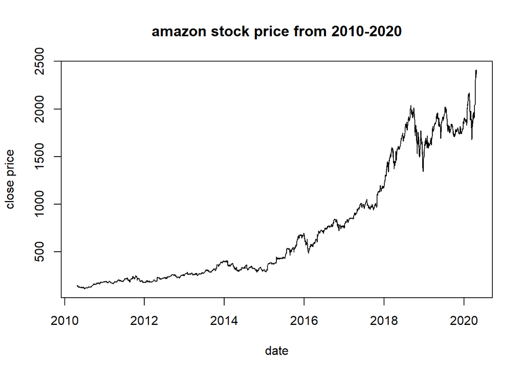

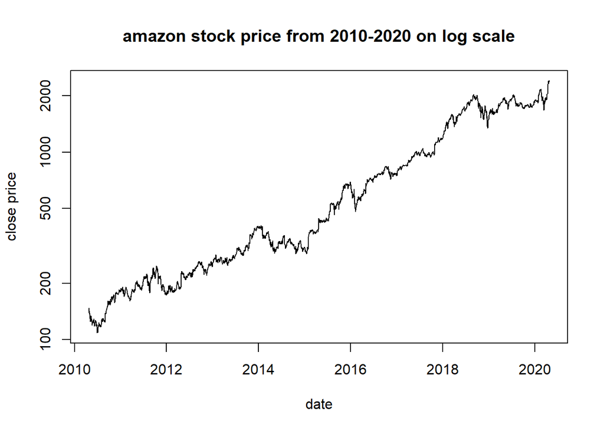

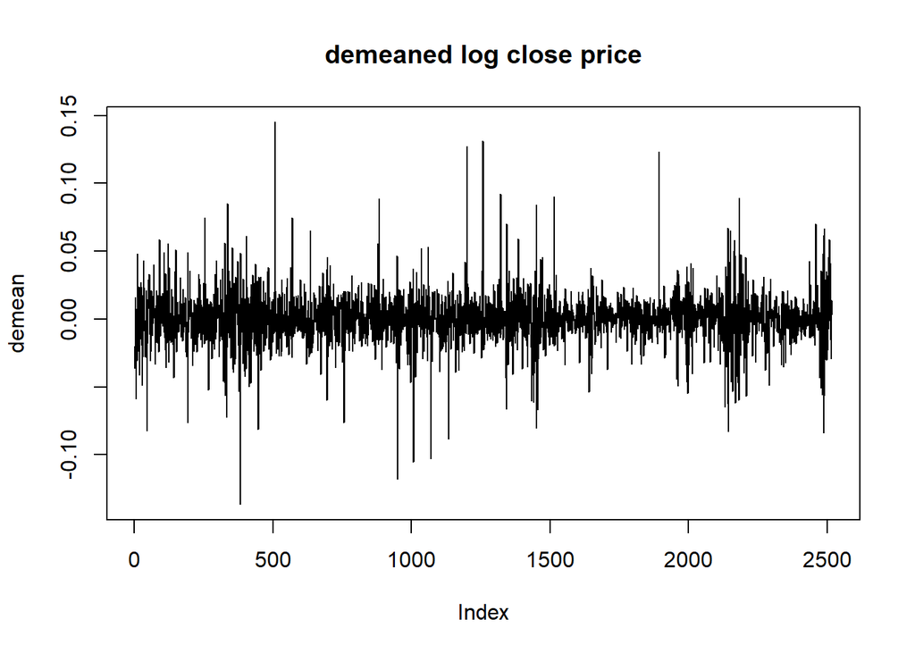

## ARMA? ARIMA? Auto-ARIMA?

### ARMA with mean difference data

Here is some information about ARIMA model:

Here, the way I fit with ARIMA is actually fit ARMA with the demeaned data. In other words, I have already calculated the difference and then fit the processed data to the ARMA model. Therefore, below is the set up for the ARMA model.

In the mathematical formula, an ARMA{p,q} model is defined by
$$Y_n = \mu + \phi_1(Y_{n-1} - \mu) + \phi_2(Y_{n-2} - \mu) + ... + \phi_p(Y_{n-p} - \mu) + \epsilon_n + \psi_1\epsilon_{n-1} + ... + \psi_q\epsilon_{n-q}$$

The assumption for the ARMA model is stationary, and error term $\epsilon$ are idd, drawn from $N(0, \sigma^2)$  
To choose the best ARMA(p,q) model, we could use Akaike information criteria (AIC) values to help us make that decision. Recall that lower AIC values mean better fits. Below are the AIC values from ARIMA(0,0) to ARIMA(5,5)

|  | MA0 | MA1 | MA2 | MA3 | MA4 | MA5 |
| --- | --- | --- | --- | --- | --- | --- |
| AR0 | -12602.60 | -12601.59 | -12599.79 | -12598.16 | -12598.47 | -12597.26 |
| AR1 | -12601.57 | -12600.34 | -12600.41 | -12598.64 | -12601.50 | -12599.51 |
| AR2 | -12599.76 | -12597.76 | -12601.10 | -12595.86 | -12599.51 | -12597.49 |
| AR3 | -12598.09 | -12596.86 | -12604.17 | -12607.32 | -12605.28 | -12604.65 |
| AR4 | -12598.33 | -12601.84 | -12599.82 | -12605.31 | -12606.20 | -12601.30 |
| AR5 | -12596.97 | -12594.96 | -12603.85 | -12602.33 | -12604.22 | -12600.90 |

As we could see from the AIC table, the model with the lowest AIC is ARIMA(3,1,3) with AIC value -12607.32. This model has moderate complexity and the lowest AIC value. Therefore, if we want to model Amazon stock with the ARIMA model, ARIMA(3,1,3) should be the right choice.

### ARIMA by auto.arima

However, there is a package called forecast which has a function “auto.arima”. According to the documentation, $^{[3]}$, auto.arima returns the best ARIMA model according to either AIC, AICc, or BIC value. The function searches for a possible model within the order constraints provided. Therefore, I will fit the adjusted close price on the log scale with auto.arima to see how the result will be different from what I did above.

Also, if interested, the information of ARIMA model could be found at reference $^{[6]}$

```
## Series: AMZN$log_close
## ARIMA(1,1,1) with drift
## Box Cox transformation: lambda= 1.174328
##
## Coefficients:
##          ar1      ma1   drift
##       0.9017  -0.9189  0.0015
## s.e.  0.1104   0.1026  0.0004
##
## sigma^2 estimated as 0.0007349:  log likelihood=5511.08
## AIC=-11014.16   AICc=-11014.14   BIC=-10990.84
##
## Training set error measures:
##                         ME       RMSE        MAE         MPE      MAPE
## Training set -1.115879e-05 0.01975801 0.01356845 -0.00144157 0.2241459
##                   MASE         ACF1
## Training set 0.9960286 -0.003931504
```

We could see here the choice becomes different from auto.arima. Now auto.arima suggests I should use ARIMA(1,1,1) instead of ARIMA(3,1,3), even before with ARIMA(3,1,3), I reach to an AIC value of -12607.32, and with auto.arima, the ARIMA(1,1,1) only has an AIC value of -11014.16. In the next step, I will try to do some forecasting the price of Amazon stock for the next 30 days, and try to construct a confidence interval with ARIMA(1,1,1). Let’s see what will happen.

### Forecasting 30 days of stock price with ARIMA(1,1,1) and Condifence Interval

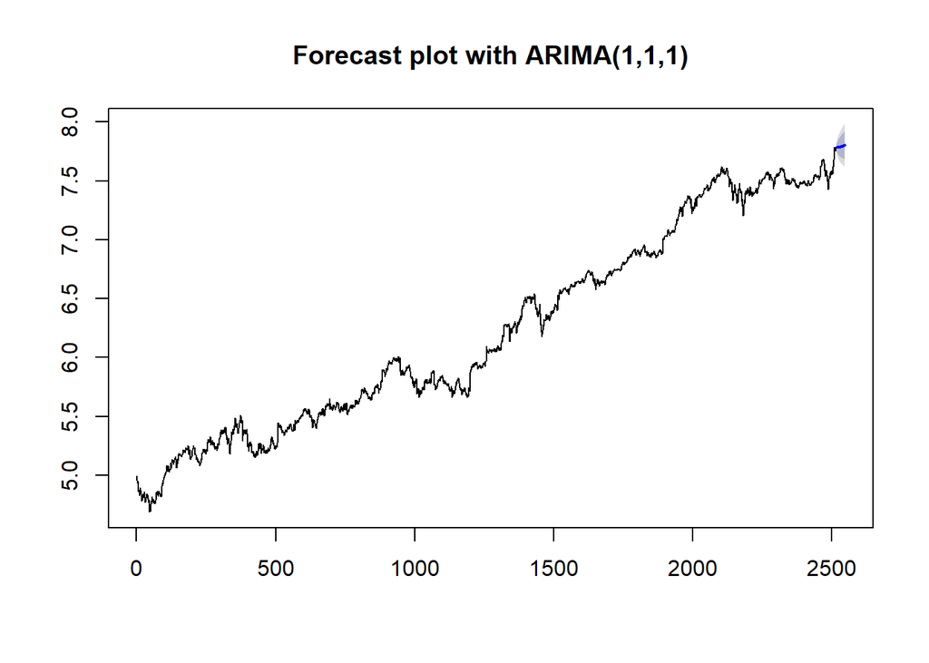

```r
price_forecast <- forecast(modelfit, h=30)
plot(price_forecast, main="Forecast plot with ARIMA(1,1,1)")
```

As we could see in this plot, ARIMA(1,1,1) predicted an increasing trend. We could identify this by the solid blue line, which slightly pointing upward. Moreover, one nice thing about the forecast package is that it will also provide confidence intervals. The two confidence intervals presented by default is 80% CI and 95% CI. Now let’s take a look at what those numbers are. One thing we need to keep in mind is that our value is currently on the log scale. To make the result looks make sense, we need to perform an exponential transformation first.

```r
# Confidence interval
CI <- as.data.frame(cbind(exp(price_forecast$lower), exp(price_forecast$upper)))
CI
```

```
##    exp(price_forecast$lower).80% exp(price_forecast$lower).95%
## 1                       2350.712                      2320.656
## 2                       2326.620                      2285.006
## 3                       2308.784                      2258.702
## 4                       2294.343                      2237.391
## 5                       2282.156                      2219.349
## 6                       2271.617                      2203.668
## 7                       2262.356                      2189.796
## 8                       2254.122                      2177.365
## 9                       2246.736                      2166.115
## 10                      2240.064                      2155.851
## 11                      2234.000                      2146.423
## 12                      2228.464                      2137.716
## 13                      2223.387                      2129.634
## 14                      2218.713                      2122.099
```

[output cut: 47 more lines]

Just to keep in mind that the adjusted close price on 4/24/2020 is $2,410.22. According to ARIMA(1,1,1) model, if we use a 95% confidence interval, that value could be either as low as $2,043.438, or as high as $2,926.585. So another way to think about this is if you bought one stock of Amazon on 4/24/2020, according to ARIMA(1,1,1) model, after one month, in most extreme cases, you could either lose $366.79, or gain a whooping $516.37. However, most likely, the number should be somewhere between. And that is the beauty of the stock market: higher risk, higher return. And that is why so many people, including me, were so into it.

### Training / Testing Split and Model Validation

One final thing is we cannot validate the model without talking about training/testing split. And here we go. Let’s split the original data to the first 70% as the training set, and the last 30% as the testing set. Still, we will work on the adjusted close price, and we will work on the log scale. Let’s see how our model fits the data. Again, since the data is on the log scale, we should always remember to do the exponential transformation to make the result easier to interpret.

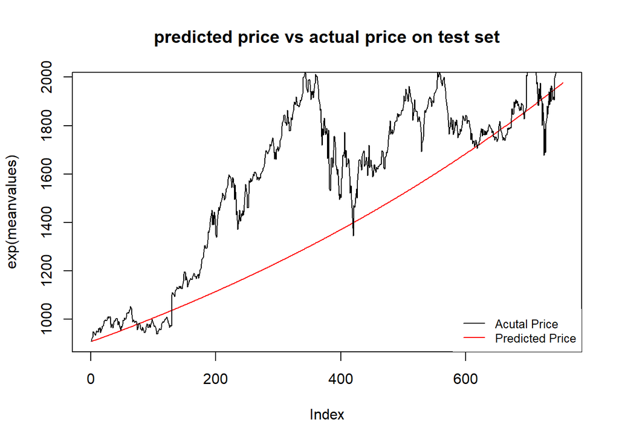

## GARCH $^{[1]}$

The generalized ARCH model, known as GARCH(p,q), has the form
$$Y_n=\epsilon_n\sqrt{V_n}$$

where
$$V_n=a_0+\sum_{j=1}^pa_jY_{n-j}^2+\sum_{k=1}^qb_kY_{n-k}^2$$
and $\epsilon_{1:N}$ is white noise.

The GARCH(1.1) model is a popular choice (Cowpertwait and Metcalfe; 2009) which can be fitted using garch() in the tseries R package.

```r
## ----garch--------------------------------------------------------------------
require(tseries)
fit.garch = garch(demean, order = c(1,1), grad = "numerical", trace = FALSE)
L.garch <- tseries:::logLik.garch(fit.garch)
L.garch
```

```
## 'log Lik.' 6338.532 (df=3)
```

This 3-parameter model has a maximized log likelihood of 6338.532 with degree of freedom equals to 3.

## GARCH take two

```
## $fit
##
## *----------------------------------*
## *          ARFIMA Model Fit        *
## *----------------------------------*
## Mean Model   : ARFIMA(2,0,1)
## Distribution : norm
##
## Optimal Parameters
## ------------------------------------
##        Estimate  Std. Error    t value Pr(>|t|)
## mu     4.994316    0.012562    397.572        0
## ar1    1.931343    0.000033  59354.179        0
## ar2   -0.932522    0.000046 -20259.137        0
## ma1   -0.701365    0.004720   -148.600        0
## sigma  0.021772    0.000278     78.274        0
##
## Robust Standard Errors:
##        Estimate  Std. Error    t value Pr(>|t|)
## mu     4.994316    0.016680    299.420        0
## ar1    1.931343    0.000047  41330.944        0
## ar2   -0.932522    0.000081 -11564.163        0
## ma1   -0.701365    0.013129    -53.419        0
## sigma  0.021772    0.000739     29.463        0
##
## LogLikelihood : 6063.859
##
## Information Criteria
## ------------------------------------
##
## Akaike       -4.8124
## Bayes        -4.8009
## Shibata      -4.8124
## Hannan-Quinn -4.8082
##
## Weighted Ljung-Box Test on Standardized Residuals
## ------------------------------------
##                          statistic   p-value
## Lag[1]                       38.68 4.998e-10
## Lag[2*(p+q)+(p+q)-1][8]      58.09 0.000e+00
```

[output cut: 55 more lines]

```
## 17   0   1   1   0  0   0  -0.66145572         1
## 18   0   1   0   1  0   0  -0.61035969         1
## 19   0   1   0   0  0   0  -0.47549639         1
## 20   0   0   1   1  1   0   0.09041063         1
## 21   0   0   1   0  1   0   1.20805556         1
## 22   0   0   0   1  1   0   1.23094917         1
## 23   0   0   0   0  1   0   2.54121339         1
## 24   0   0   1   1  0   0   3.93613037         1
## 25   0   0   1   0  0   0   5.15543541         1
## 26   0   0   0   1  0   0   5.16492137         1
## 27   0   1   1   1  1   0 101.03540216         1
## 28   1   1   0   0  0   0           NA         0
## 29   1   1   1   0  0   0           NA         0
## 30   0   1   0   1  1   0           NA         0
## 31   1   1   1   1  1   0           NA         0
```

With the parameters collected, we choose ARFIMA (2,0,1) and incorporate the parameters into a garch model.

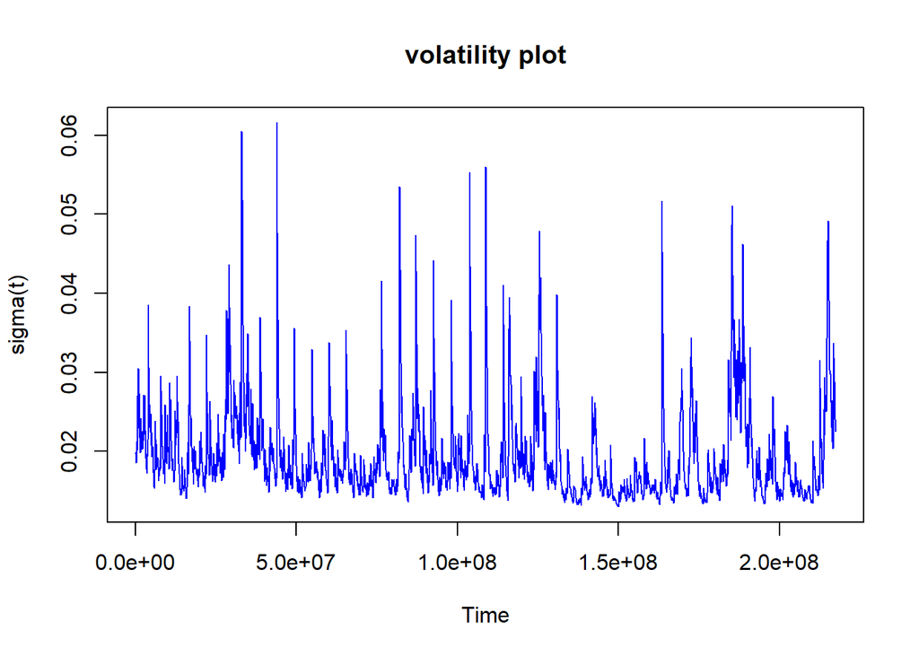

As we could see, the volatility is somehow stationary with respect to time. Now let’s see how the combined model performs and how the prediction looks like.

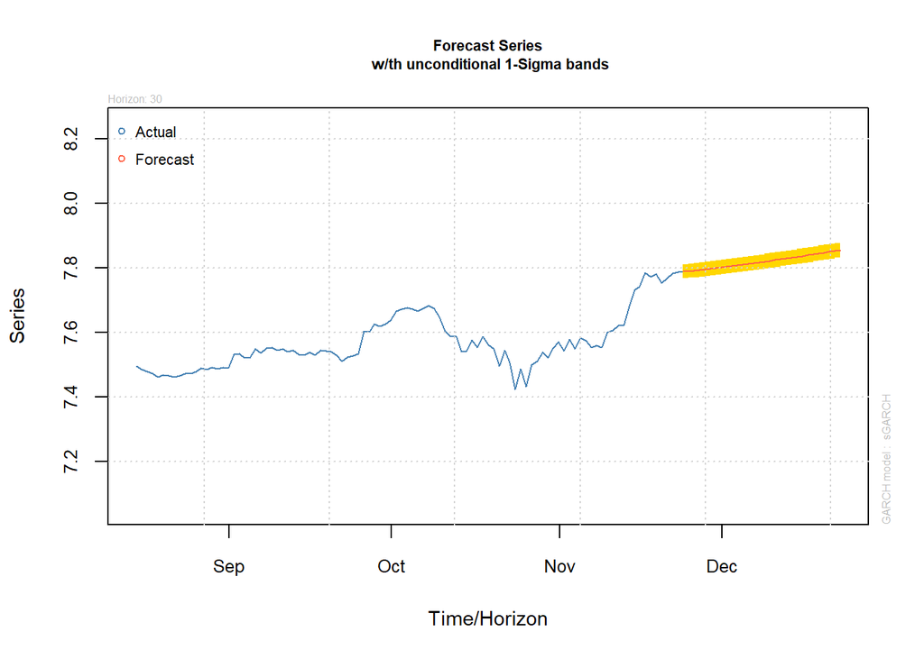

## Pomp model with financial leverge $^{[1]}$ $^{[2]}$

As we fitted the GARCH model before, we noticed that GARCH is more like a black box model, and it’s parameters don’t have a clear interpretation. To develop and test the hypothesis, we need the help of a pomp model.

“$R_n$ is formally defined as leverage on day n as the correlation between index return on day (n-1) and the inincrease in the log volatility from day (n-1) to day n.” Here, we introduce a pomp implementation of Breto (2014), which models $R_n$ as a random walk on a transformed scale
$$R_n=\frac{exp(2G_n)-1}{exp(2G_n)+1}$$
where $G_n$ is the usual, Gaussian random walk.

$$Y_n=exp(H_n/2)\epsilon_n$$
$$H_n=\mu_h(1-\phi)+\phi H_{n-1}+\beta_{n-1}R_nexp(-H_{n-1}/2)+W_n$$
$$G_n=G_{n-1}+v_n$$
where $\beta_n=Y_n\sigma_{\eta}\sqrt{1-\phi^2}$, $\epsilon_n \sim i.i.d. N(0,1)$, $v_n \sim i.i.d. N(0,\sigma_v^2)$, and $w_n \sim i.i.d. N(0,\sigma_{\omega}^2)$

Here, we choose the iterated filtering algorithm (IF2) to converge toward the region of parameter space maximizing the maximum likelihood. In this case, we use the state variable $X_n=(G_n,H_n,Y_n)$.

To determinene a recursive particle filter, we write the filtered particle j at time n - 1 as

$$X_{n-1,j}^F=(G_{n-1,j}^F,H_{n-1,j}^F,y_{n-1}^*)$$

Now we can construct prediction particles at time n,
$$(G_{n,j}^p,H_{n,j}^p)\sim f_{G_n,H_n|G_{n-1},H_{n-1},Y_{n-1}}(g_n|G_{n-1,j}^F,H_{n-1,j}^F,y_{n-1}^*)$$
with corresponding weight $w_{n,j}=f_{Y_n|G_n,H_n}(y_n^*|G_{n,j}^P,H_{n,j}^P)$

```r
## ----names--------------------------------------------------------------------
amzn_statenames <- c("H","G","Y_state")
amzn_rp_names <- c("sigma_nu","mu_h","phi","sigma_eta")
amzn_ivp_names <- c("G_0","H_0")
amzn_paramnames <- c(amzn_rp_names,amzn_ivp_names)
amzn_covarnames <- "covaryt"

## ----rproc--------------------------------------------------------------------
rproc1 <- "
  double beta,omega,nu;
  omega = rnorm(0,sigma_eta * sqrt( 1- phi*phi ) *
    sqrt(1-tanh(G)*tanh(G)));
  nu = rnorm(0, sigma_nu);
  G += nu;
  beta = Y_state * sigma_eta * sqrt( 1- phi*phi );
  H = mu_h*(1 - phi) + phi*H + beta * tanh( G )
    * exp(-H/2) + omega;
"
rproc2.sim <- "
  Y_state = rnorm( 0,exp(H/2) );
 "

rproc2.filt <- "
  Y_state = covaryt;
 "
amzn_rproc.sim <- paste(rproc1,rproc2.sim)
amzn_rproc.filt <- paste(rproc1,rproc2.filt)


## ----rinit--------------------------------------------------------------------
amzn_rinit <- "
  G = G_0;
  H = H_0;
  Y_state = rnorm( 0,exp(H/2) );
"


## ----measure------------------------------------------------------------------
amzn_rmeasure <- "
   y=Y_state;
"

amzn_dmeasure <- "
   lik=dnorm(y,0,exp(H/2),give_log);
"


## ----transforms---------------------------------------------------------------
amzn_partrans <- parameter_trans(
  log=c("sigma_eta","sigma_nu"),
  logit="phi"
)


## ----sp_pomp------------------------------------------------------------------
amzn.filt <- pomp(data=data.frame(
    y=demean,time=1:length(demean)),
  statenames=amzn_statenames,
  paramnames=amzn_paramnames,
  times="time",
  t0=0,
  covar=covariate_table(
    time=0:length(demean),
    covaryt=c(0,demean),
    times="time"),
  rmeasure=Csnippet(amzn_rmeasure),
  dmeasure=Csnippet(amzn_dmeasure),
  rprocess=discrete_time(step.fun=Csnippet(amzn_rproc.filt),
    delta.t=1),
  rinit=Csnippet(amzn_rinit),
  partrans=amzn_partrans
)

## ----run_level----------------------------------------------------------------
run_level <- 3
amzn_Np <-           switch(run_level, 100, 1e3, 2e3)
amzn_Nmif <-         switch(run_level,  10, 100, 200)
amzn_Nreps_eval <-   switch(run_level,   4,  10,  20)
amzn_Nreps_local <-  switch(run_level,  10,  20,  20)
amzn_Nreps_global <- switch(run_level,  10,  20, 100)

## ----sim_pomp-----------------------------------------------------------------
params_test <- c(
  sigma_nu = exp(-4.5),
  mu_h = -0.25,
  phi = expit(4),
  sigma_eta = exp(-0.07),
  G_0 = 0,
  H_0=0
)



## ----parallel-setup,cache=FALSE-----------------------------------------------
library(doRNG)
```

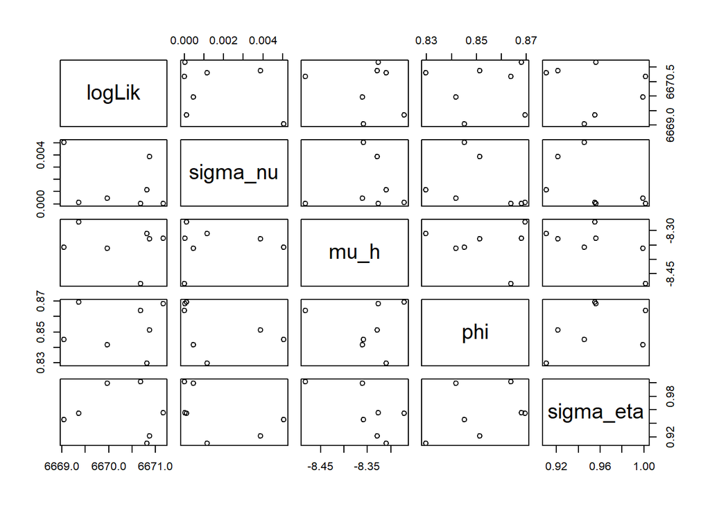

```r
registerDoRNG(34118892)


## ----mif_setup----------------------------------------------------------------
amzn_rw.sd_rp <- 0.02
amzn_rw.sd_ivp <- 0.1
amzn_cooling.fraction.50 <- 0.5
amzn_rw.sd <- rw.sd(
  sigma_nu  = 0.02,
  mu_h      = 0.02,
  phi       = 0.02,
  sigma_eta = 0.02,
  G_0       = ivp(0.1),
  H_0       = ivp(0.1)
)

## ----box----------------------------------------------------------------------
amzn_box <- rbind(
 sigma_nu=c(0.005,0.05),
 mu_h    =c(-1,0),
 phi = c(0.95,0.99),
 sigma_eta = c(0.5,1),
 G_0 = c(-2,2),
 H_0 = c(-1,1)
)
varName <- c("amzn_rw.sd", "amzn.filt", "params_test", "amzn_Np", "amzn_Nmif", "amzn_cooling.fraction.50", "amzn_Nreps_eval", "amzn_box")
stew(file=sprintf("mif1-%d.rda",run_level),{
  t.if1 <- system.time({
  if1 <- foreach(i=1:amzn_Nreps_local,
    .packages='pomp', .combine=c, .export=varName) %dopar% mif2(amzn.filt,
      params=params_test,
      Np=amzn_Np,
      Nmif=amzn_Nmif,
      cooling.fraction.50=amzn_cooling.fraction.50,
      rw.sd = amzn_rw.sd)
  L.if1 <- foreach(i=1:amzn_Nreps_local,
    .packages='pomp', .combine=rbind, .export=varName) %dopar% logmeanexp(
      replicate(amzn_Nreps_eval, logLik(pfilter(amzn.filt,
        params=coef(if1[[i]]),Np=amzn_Np))), se=TRUE)
  })
},seed=318817883,kind="L'Ecuyer")


r.if1 <- data.frame(logLik=L.if1[,1],logLik_se=L.if1[,2],
  t(sapply(if1,coef)))
if (run_level>1) write.table(r.if1,file="amzn_params.csv",
  append=TRUE,col.names=FALSE,row.names=FALSE)

## ----pairs_plot,echo=F,eval=T,out.width="11cm"--------------------------------
pairs(~logLik+sigma_nu+mu_h+phi+sigma_eta,
  data=subset(r.if1,logLik>max(logLik)-20))
```

```r
## ----box_eval-----------------------------------------------------------------
stew(file=sprintf("box_eval-%d.rda",run_level),{
  t.box <- system.time({
    if.box <- foreach(i=1:amzn_Nreps_global,
      .packages='pomp',.combine=c, .export = c("if1", "amzn_box")) %dopar% mif2(if1[[1]],
        params=apply(amzn_box,1,function(x)runif(1,x)))
    L.box <- foreach(i=1:amzn_Nreps_global,
      .packages='pomp',.combine=rbind, .export = varName) %dopar% {
         logmeanexp(replicate(amzn_Nreps_eval, logLik(pfilter(
         amzn.filt,params=coef(if.box[[i]]),Np=amzn_Np))),
           se=TRUE)
       }
  })
},seed=290860873,kind="L'Ecuyer")

r.box <- data.frame(logLik=L.box[,1],logLik_se=L.box[,2],
  t(sapply(if.box,coef)))
if(run_level>1) write.table(r.box,file="amzn_params.csv",
  append=TRUE,col.names=FALSE,row.names=FALSE)
summary(r.box$logLik,digits=5)
```

```
##    Min. 1st Qu.  Median    Mean 3rd Qu.    Max.
##    6585    6600    6608    6629    6670    6673
```

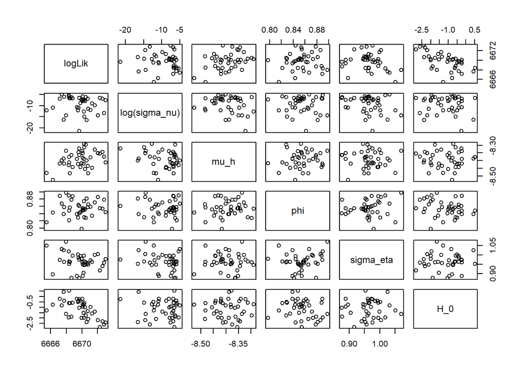

```r
## ----pairs_global_plot,eval=T,echo=F,out.width="11cm"-------------------------
pairs(~logLik+log(sigma_nu)+mu_h+phi+sigma_eta+H_0,
  data=subset(r.box,logLik>max(logLik)-10))
```

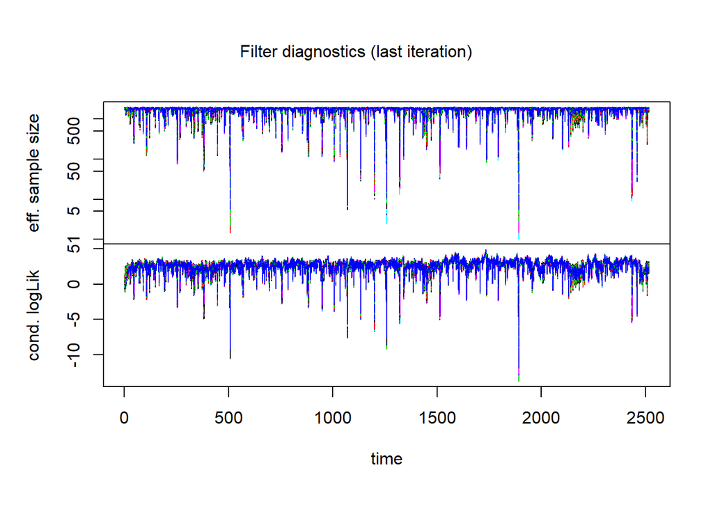

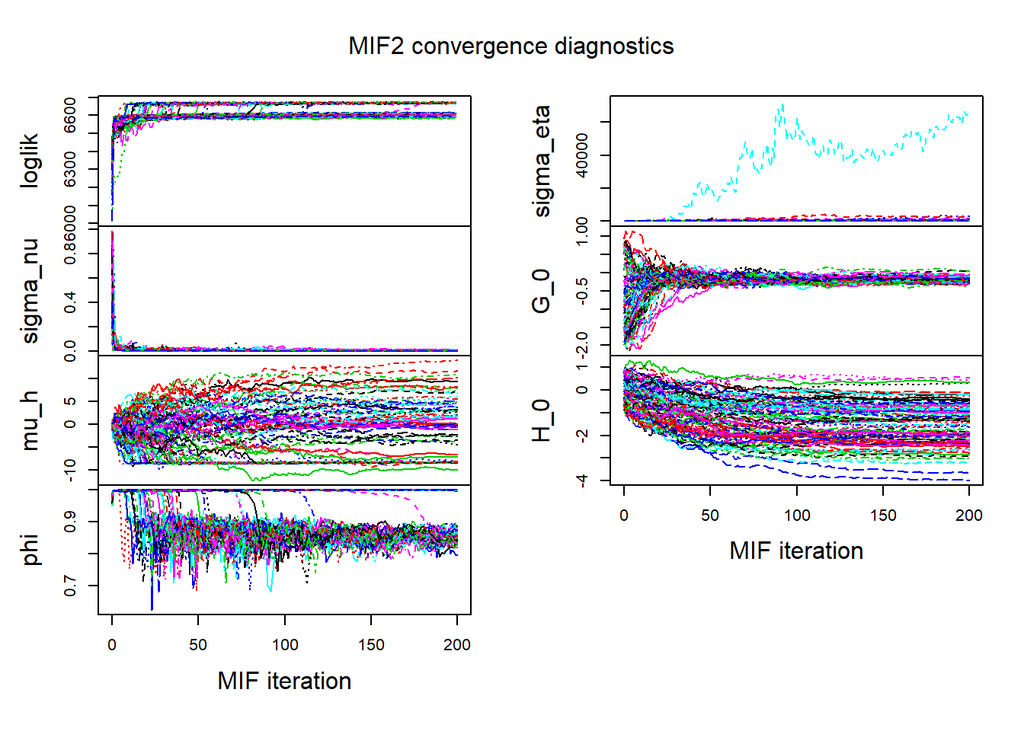

```r
plot(if.box)
```

## Compare GARCH with Pomp model

```r
## ----garch_benchmark,eval=F,echo=F--------------------------------------------
library(tseries)
fit.garch.benchmark <- garch(demean,grad = "numerical", trace = FALSE)
L.garch.benchmark <- tseries:::logLik.garch(fit.garch.benchmark)
L.garch.benchmark
```

```
## 'log Lik.' 6338.532 (df=3)
```

```r
# Log likelihood with Pomp
summary(r.box$logLik,digits=5)
```

```
##    Min. 1st Qu.  Median    Mean 3rd Qu.    Max.
##    6585    6600    6608    6629    6670    6673
```

As we could see, the benchmark GARCH has log-likelihood of 6338.532. However, with the pomp model, the minimum value of log-likelihood is 6585. That brings the point why we should try out pomp model.

## Summary

In a word, about all the analysis I did above, I personally think it’s still a good time to hold amazon stocks since due to our model, the price should increase in the future. However, this is just a report for a class project, and any result I came up with cannot be treated as a piece of financial advice. I hope everyone reading this report could achieve financial success in the future.

## Refernece

1. Lecture Notes 14
2. https://ionides.github.io/531w18/final_project/1/final.html#conclu
3. https://www.rdocumentation.org/packages/forecast/versions/8.12/topics/auto.arima
4. https://rpubs.com/kapage/523169
5. ARFIMA model: https://en.wikipedia.org/wiki/Autoregressive_fractionally_integrated_moving_average
6. ARIMA model: https://en.wikipedia.org/wiki/Autoregressive_integrated_moving_average